# FordGoBike Data Exploration

### by Hiver

## Overview

```
In this investigation of the Ford GoBike System, I'm most interested in figuring out users habits, inclus:
```

- When are the rush time of renting bike?
- Where are their favorite places ?
- How far they usually go ?
- How long they take the trips ?
- Is there different habits between subscriber and occasional customers?

## Dataset Overview

```
- Ford GoBike is the Bay Area's bike share system with 700 bikes and 70 stations and will grow to 7,000 across San Francisco and San Jose. Riders can unlocked the bike from one station and returned to any other station.The bikes are available for use 24 hours/day, 7 days/week, 365 days/year and riders have access to all bikes in the network when they become a member or purchase a pass.

- In this investigation, I download the data in 7 consecutifs months from 9/2019 - 3/2020. It includes 1698486 rows of data with 15 features. Half of them are in numerics, and half are in object. I just take a sample of 16984 rows to work with to ensure the data enough large but also not hard to computing.
```

## Distribution of usage time of one bike in one session

- The renting time each session follow the normal distribution. Almost riders take a short trip in 10 minutes, it's far from the limit of 30 minutes and only 5% exceed that limit. The red line is the limit of quantile 95%

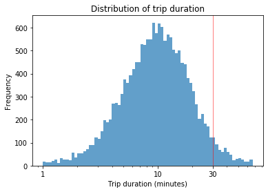

```python
# Riders's regular trip duration (minutes) ?
log_binsize = 0.025
bins = 10 ** np.arange(0, np.log10(df.duration_min.quantile(0.99))+log_binsize, log_binsize)

plt.hist(x = df.duration_min, bins = bins, alpha = 0.7)
plt.xscale('log')
plt.xticks([1e0, 1e1, 3e1], [1, 10, 30])
plt.ylabel('Frequency')
plt.xlabel('Trip duration (minutes)');
plt.title('Distribution of trip duration');
plt.axvline(df.duration_min.quantile(0.95), linewidth=1, color='r', alpha = 0.5);
```

## Distribution of rider's trip

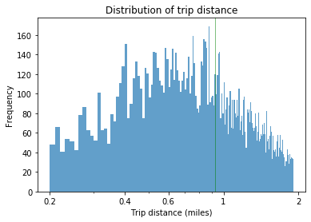

```python
# plot
bins = np.arange(0.2, np.log(df['distance'].max())+0.01, 0.01)
sb.distplot(dist, bins = bins, kde = False,
            hist_kws = {'alpha' : 0.7});
plt.xscale('log')
plt.xticks([2e-1, 4e-1, 6e-1, 1e0, 2e0], [0.2, 0.4, 0.6, 1, 2])
plt.ylabel("Frequency");
plt.xlabel('Trip distance (miles)')
plt.title('Distribution of trip distance');
plt.axvline(df['distance'].quantile(0.5), linewidth=1, color='g', alpha = 0.5);
```

## The rush renting time

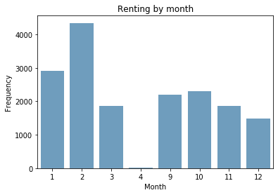

```python
# To answer, let's explore the frequency of the renting by time (month, day_of_week,time_in_day)
base_color = sb.color_palette()[0]

sb.countplot(data = df, x = 'month', color = base_color, alpha = 0.7)
plt.xlabel("Month")
plt.ylabel("Frequency")
plt.title("Renting by month");
```

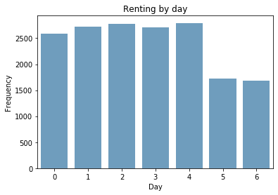

```python
sb.countplot(data = df, x = 'day_of_week', color = base_color, alpha = 0.7)
plt.xlabel("Day")
plt.ylabel("Frequency")
plt.title("Renting by day");
```

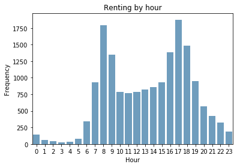

```python
sb.countplot(data = df, x = 'time_in_day', color = base_color, alpha = 0.7)
plt.xlabel("Hour")
plt.ylabel("Frequency")
plt.title("Renting by hour");
```

## Bike sharing and rental access method of differents user types

- It can be seen that if user subscribes, they will rent more frequently
- User prefer using app than clipper and they don't really like bike sharing for all trip
- Although these factors don't drive people to rent or not but if we make things more convenient as users like and good marketing strategies, we can keep and increase the number of users

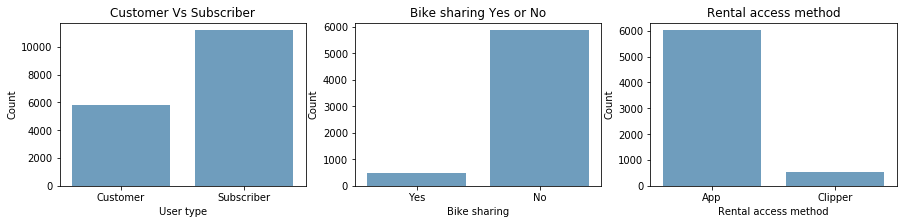

```python
fig, ax = plt.subplots(1,3, figsize = [15,3])
ax1 = sb.countplot(data = df, x = 'user_type', color = base_color, ax=ax[0], alpha = 0.7)
ax1.set_title("Customer Vs Subscriber")
ax1.set_ylabel("Count")
ax1.set_xlabel("User type")

# Ignore rows with no_data
data_plot = df.query("bike_share_for_all_trip != 'no_data'")
ax2 = sb.countplot(data = data_plot, x = 'bike_share_for_all_trip', color = base_color, ax=ax[1], alpha = 0.7)
ax2.set_title("Bike sharing Yes or No")
ax2.set_ylabel("Count")
ax2.set_xlabel("Bike sharing")

# Ignore rows with no_data
data_plot = df.query("rental_access_method != 'no_data'")
ax3 = sb.countplot(data = data_plot, x = 'rental_access_method', color = base_color, ax=ax[2],alpha = 0.7);
ax3.set_title("Rental access method")
ax3.set_ylabel("Count")
ax3.set_xlabel("Rental access method");
```

## The rider's most popular trips ?

- Below is the top 10 favorite places of riders and their frequency

[figure not shown]

```python
plt.figure(figsize=[12, 5])
#filter the row with no_data
data_plot = df.query("start_station_name != 'no_data'")
data_plot = data_plot.query("end_station_name != 'no_data'")
#ploting
data_plot['Trip_name'] = data_plot['start_station_name'] + " / " + data_plot['end_station_name']
d = data_plot.groupby(['Trip_name']).size() \
                      .reset_index(name = 'Number_of_trips') \
                      .sort_values(by ='Number_of_trips', ascending=False)
d[:10].plot.barh(x = 'Trip_name', y = 'Number_of_trips');
plt.title("Top 10 popular trips");
plt.xlabel('Number of Trips');
plt.ylabel('Trips names');
```

## Does subscriber usually rent longer than occasional customers ?

- From the boxplot, we can see the renting duration of occasional customers is slightly longer than subscribers.
- The violinplot shows that subscribers have a renting time more stable than occasional customers (almost people rent with the mean duration while with occasional customers, the renting time varies more)

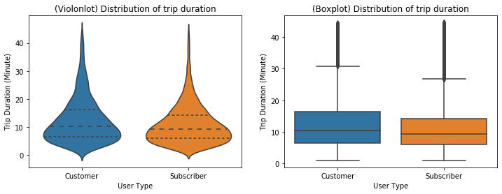

```python
# As above, the duration have very large outliers.
# So, for better visualisation, just use quantile(0.99) to plot
plt.figure(figsize = [12, 4])

plt.subplot(1, 2, 1)
sb.violinplot(data=data_99, x='user_type', y='duration_min', inner='quartile');
plt.xlabel('User Type');
plt.ylabel('Trip Duration (Minute)');
plt.title('(Violonlot) Distribution of trip duration');

plt.subplot(1, 2, 2)
ax2 = sb.boxplot(data=data_99, x='user_type', y='duration_min');
plt.xlabel('User Type');
plt.ylabel('Trip Duration (Minute)');
plt.title('(Boxplot) Distribution of trip duration');
```